# DATA 607 Project 1

# Group Name: SPARK

#### Group Members and Contributors:

- [Santosh Cheruku](https://github.com/san123i)
- [Samantha Deokinanan](https://github.com/greeneyefirefly)
- [Rajwant Mishra](https://github.com/rajwantmishra)
- [Priya Shaji](https://github.com/PriyaShaji)

#### Github

All the project work and graphics are availble under github [Project Page](https://github.com/PriyaShaji/ms-project-607_1).

# Problem Statement

In this project, we’re given a text file with chess tournament results where the information has some structure.The task is to generate a .CSV file (that could for example be imported into a SQL database) with the following information for all of the players:

| Player’s Name | Player’s State | Total Number of Points | Player’s Pre-Rating | Average Pre-Chess Rating of Opponents |
| --- | --- | --- | --- | --- |
| GARY HUA | ON | 6.0 | 1794 | 1605 |

**Data in Text File**

The chess tournament text file is written in a format that is not legible in R as it is. This file needs to be restructured in order to find the average pre-tournament score.

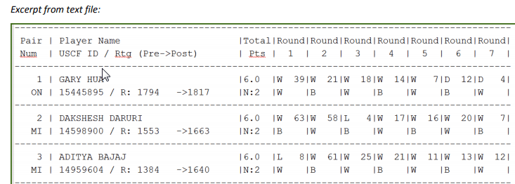

# Summary of the Approaches

Each contributor decided to work on a solution in order to identify the different ways this task can be solved. However, there were key steps we took which were similar.

#### Extract

1. Loading the specific R packages we felt that could solve this problem easily.

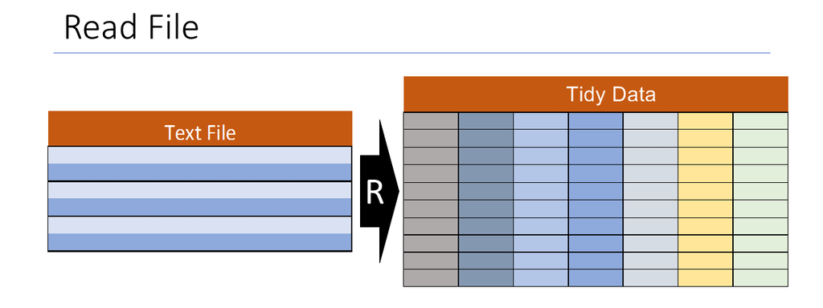

#### Transform

2. The different methods of cleaning and formatting with text file

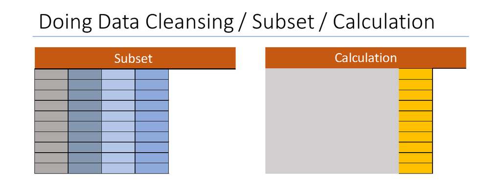

#### Publish

3. Lastly, building and exporting the final CSV

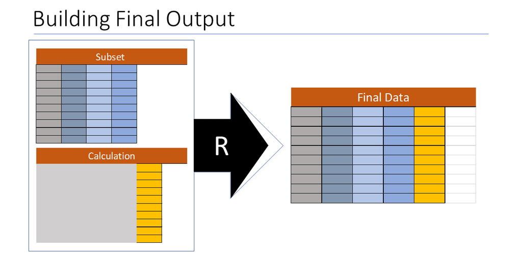

# Solution

#### The Text File

The chess tournament text file is written in a format that is not legible in R as it is. This file needs to be restructured in order to find the average pre-tournament score.

```
## [1] " Pair | Player Name                     |Total|Round|Round|Round|Round|Round|Round|Round| "
## [2] " Num  | USCF ID / Rtg (Pre->Post)       | Pts |  1  |  2  |  3  |  4  |  5  |  6  |  7  | "
## [3] "-----------------------------------------------------------------------------------------"
## [4] "    1 | GARY HUA                        |6.0  |W  39|W  21|W  18|W  14|W   7|D  12|D   4|"
## [5] "   ON | 15445895 / R: 1794   ->1817     |N:2  |W    |B    |W    |B    |W    |B    |W    |"
## [6] "-----------------------------------------------------------------------------------------"
```

#### Final CSV Output

Once all the rigorous formatting was carried out, the final, workable data frame now has the format below.

|  | PlayerName | State | Total Points | Pre rating | Avg Opp Rating |
| --- | --- | --- | --- | --- | --- |
| 1 | GARY HUA | ON | 6.0 | 1794 | 1605 |
| 4 | DAKSHESH DARURI | MI | 6.0 | 1553 | 1469 |
| 7 | ADITYA BAJAJ | MI | 6.0 | 1384 | 1564 |
| 10 | PATRICK H SCHILLING | MI | 5.5 | 1716 | 1574 |
| 13 | HANSHI ZUO | MI | 5.5 | 1655 | 1501 |
| 16 | HANSEN SONG | OH | 5.0 | 1686 | 1519 |
| 19 | GARY DEE SWATHELL | MI | 5.0 | 1649 | 1372 |
| 22 | EZEKIEL HOUGHTON | MI | 5.0 | 1641 | 1468 |
| 25 | STEFANO LEE | ON | 5.0 | 1411 | 1523 |
| 28 | ANVIT RAO | MI | 5.0 | 1365 | 1554 |

[output cut: 54 more lines]

#### The R Package

`stringr` was the main package needed to solve this problem, while many other package were utilized to perfrom data wrangling (`dplyr` , `tidyverse`) and create a presentable R markdown page `rmdformats` .

```r
library(stringr)
library(tidyverse)
library(dplyr)
```

### Key Methods Used To Restructure the .txt file into the Dataframe

#### Pattern Replacement Methods

**Check Code**

These are the different steps we took to identify and replace specific characters from the text file in order to convert the text into a data frame.

##### *Method 1*

** Using read_lines **

```r
# ----------------------------------------------------------#
# Read the File from Local and Skip the 1st row "----------"
# ----------------------------------------------------------#

cd2 <-read_lines("tournamentinfo.txt",skip = 1)

# ----------------------------------------------------------#
# Replace all "------" by NA
# Read only data apart from header
# ----------------------------------------------------------#

cd2_data <- unlist(str_replace_all(cd2,"(-{89})","NA"))[-c(1:3)]
cd2_head <- unlist(str_replace_all(cd2,"(-{89})","NA"))[c(1:2)]

# ----------------------------------------------------------#
# Extracting common patterns data in dataframe , and remvoing
# leading or trailing sapces.
# ----------------------------------------------------------#
tempFull_Data <-  trimws(unlist(str_extract_all(cd2_data,"[[:alpha:]-? ?]{2,}|[\\d.?\\d? +]{2,}|[\\d +]{1,2}|[\\w:?\\d? +]{2,}",simplify = TRUE)))
tempFull_Data <- as.data.frame(tempFull_Data, stringsAsFactors=F)

# ----------------------------------------------------------#
# Removing All NA for 1st column , As it belongs to 3rd row
# in text file with Seprator which was repalced by NA.
# ----------------------------------------------------------#
tempFull_Data <- tempFull_Data[which(!tempFull_Data$V1=="NA"),]

# ----------------------------------------------------------#
# -----------Final Data to work for next steps.
# ----------------------------------------------------------#
tempFull_Data_merged <- tempFull_Data
```

##### *Method 2*

** Using read.delim **

```r
# ----------------------------------------------------------#
# create a dataframe called chess
# extract the data from column 1 and column 2
# ----------------------------------------------------------#

tmp <- read.delim("tournamentinfo.txt", header=FALSE, sep="|", skip = 4 ,stringsAsFactors = FALSE)
chess <- data.frame(Name = tmp$V2[c(TRUE, FALSE, FALSE)], State = tmp$V1[c(FALSE, TRUE, FALSE)], Points = round(as.numeric(tmp$V3[c(TRUE, FALSE, FALSE)]), 1), Rating = integer(64), opponents_averageRating = integer(64))
chess

# ----------------------------------------------------------#
# extract the pre-rating score using regular expressions
# ----------------------------------------------------------#

tmp_rate <- str_extract(tmp$V2[c(FALSE, TRUE, FALSE)], "R:[:blank:]+[:digit:]+")
tmp_rate
chess$Rating <- as.numeric(str_extract(tmp_rate, "[:digit:]+"))

# ----------------------------------------------------------#
# include all the necessary columns in the ratings dataframe
# ----------------------------------------------------------#

ratings <- data.frame(playnum = str_trim(tmp$V1[c(TRUE, FALSE, FALSE)]), rate = chess$Rating, R1 = as.numeric(str_extract(tmp$V4[c(TRUE, FALSE, FALSE)], "[:digit:]+")), R2 = as.numeric(str_extract(tmp$V5[c(TRUE, FALSE, FALSE)], "[:digit:]+")), R3 = as.numeric(str_extract(tmp$V6[c(TRUE, FALSE, FALSE)], "[:digit:]+")), R4 = as.numeric(str_extract(tmp$V7[c(TRUE, FALSE, FALSE)], "[:digit:]+")), R5 =  as.numeric(str_extract(tmp$V8[c(TRUE, FALSE, FALSE)], "[:digit:]+")), R6 =  as.numeric(str_extract(tmp$V9[c(TRUE, FALSE, FALSE)], "[:digit:]+")), R7 =  as.numeric(str_extract(tmp$V10[c(TRUE, FALSE, FALSE)], "[:digit:]+")), avg_rate = numeric(64))
```

##### *Method 3*

** Using github url **

```r
theURL <- "https://raw.githubusercontent.com/greeneyefirefly/Data607/master/Projects/Project%201/playerdata.txt"
data <- file(theURL, open="r")
playerresult <- readLines(data)

# ----------------------------------------------------------#
# Identifying where the dashes are located
# ----------------------------------------------------------#

dash <- str_detect(playerresult, '^[-]{2,}$')

# ----------------------------------------------------------#
# Remove these rows so that there is nothing separating one player from the other
# ----------------------------------------------------------#

playerresult <- playerresult[!dash == "TRUE"]

# ----------------------------------------------------------#
# Remove/Replace the unnecessary indications of win, draw or lose, pipelines and forward slashes
## removed W, D, & L
# ----------------------------------------------------------#

playerresult <- str_remove_all(playerresult, "[WDL]")

# ----------------------------------------------------------#
## replace pipelines and slashes with commas so it can later be transfromed into a dataframe
# ----------------------------------------------------------#

playerresult <- str_replace_all(playerresult, "[|/]",",")

# ----------------------------------------------------------#
# Combine the two rows for each player
# ----------------------------------------------------------#

fnew <- c("")
for (i in seq(1, length(playerresult)-1, by = 2)){
   fnew <- c(fnew, paste(playerresult[i], playerresult[i+1], sep = "", collapse = NULL))
}
# Creating the dataframe
ChessTourn <- as.data.frame(do.call(rbind, strsplit(fnew, ",")), stringsAsFactors = FALSE)
```

#### Rigorous Cleaning of the Data Frame

**Check Code**

##### *Method 1*

** Creating two dataframes and binding the necessary data using string functions and regular expressions **

```r
# ----------------------------------------------------------#
# Create two empty data frames which can hold first and second
# rows respectively (2nd row belongs to player in 1st row)
# ----------------------------------------------------------#

tempFull_Data_first <- data.frame()
tempFull_Data_second <- data.frame()
#Iterator over full dataset and load the first and second data frames
for(rowNum in 1:nrow(tempFull_Data)) {
  if(rowNum %% 2 == 0) {
    tempFull_Data_second <- rbind(tempFull_Data_second, tempFull_Data[rowNum,])
  } else {
    tempFull_Data_first <- rbind(tempFull_Data_first, tempFull_Data[rowNum,])
  }
}

# ----------------------------------------------------------#
# Set colnames for 2nd dataframe so that it doesn't conflict
# with first dataframe i.e., from V20 to V33
# ----------------------------------------------------------#
columnNames1 <- c()
for (i in 20:33) {
  columnNames1 <- c(columnNames1, paste("V", i, sep = ""))
}
colnames(tempFull_Data_second) <- columnNames1

# ----------------------------------------------------------#
# Merge both the dataframes using cbind,
# Final Table with all info in 1 row.
# ----------------------------------------------------------#

tempFull_Data_merged <- cbind(tempFull_Data_first, tempFull_Data_second)

# ----------------------------------------------------------#
# ---Create Subset of data to only inlcude Chess Round data
# ----------------------------------------------------------#

chessRound  <- tempFull_Data_merged[,c(2,3,4,5,6,7,8,9,10,11,12,13,14,15,16,17,18,19,22,23)]

# ----------------------------------------------------------#
# Column Name R1O, R2O...R7O are indicator of Opponent of respective rounds
# ----------------------------------------------------------#
names(chessRound) <- c("PID","PName","Total","R1","R1O","R2","R2O","R3","R3O","R4","R4O","R5","R5O","R6","R6O","R7","R7O","State","Pre","Post")

# ----------------------------------------------------------#
# Convert column "Pre" to Number, by reading only 3 or 4 digits only.
# ----------------------------------------------------------#

chessRound[,18:20] <- mutate( chessRound[,18:20],
                  Pre = ifelse( str_detect(Pre,"P\\d{2}$"),
                                trimws(str_extract(Pre," \\d{3,4}")),
                                trimws(str_extract(Pre," \\d{3,4}")) ))


# ----------------------------------------------------------#
# Convert all Rounds Column
# (R1,R2,R3,R4,R5,R6,R7,R1O,R2O,R3O,R4O,R5O,R6O,R7O)to NA
# if they have  B H U . Only keep W L ANF D
# ----------------------------------------------------------#

chessRound_Temp <- mutate_at( chessRound[,1:17], vars(R1,R2,R3,R4,R5,R6,R7,R1O,R2O,R3O,R4O,R5O,R6O,R7O),
                        list(~ ifelse( str_detect(.,"B|H|U"), NA, .)))

# ----------------------------------------------------------#
# Shift all NA to end of the Row, so that we can read
# all the data one after the other .
# ----------------------------------------------------------#
# Here I am grouping the data into non-NA set and NA ,
# for each row and then using Tranpose to get it in right format.
# ----------------------------------------------------------#
chessRound_Temp <- t(apply(chessRound_Temp, 1,  function(x) c(x[!is.na(x)], x[is.na(x)])))
chessRound_Temp <- as.data.frame(chessRound_Temp,stringsAsFactors=F)
Final_Chess_Data <- data.frame(chessRound_Temp[,],chessRound[,18:20])

# ----------------------------------------------------------#
# -----------------    Rename Columns ----------------------#
# ----------------------------------------------------------#
names(Final_Chess_Data) <- c("PID","PName","Total","R1","R1O","R2","R2O","R3","R3O","R4","R4O","R5","R5O","R6","R6O","R7","R7O","State","Pre","Post")
```

##### *Method 2*

** Using str_trim ,str_extract and regular expressions **

Method 2 brilliantly cleaned and created the data frame simultaneously.

```r
# ----------------------------------------------------------#
# include all the necessary columns in the ratings dataframe
# ----------------------------------------------------------#

ratings <- data.frame(playnum = str_trim(tmp$V1[c(TRUE, FALSE, FALSE)]), rate = chess$Rating, R1 = as.numeric(str_extract(tmp$V4[c(TRUE, FALSE, FALSE)], "[:digit:]+")), R2 = as.numeric(str_extract(tmp$V5[c(TRUE, FALSE, FALSE)], "[:digit:]+")), R3 = as.numeric(str_extract(tmp$V6[c(TRUE, FALSE, FALSE)], "[:digit:]+")), R4 = as.numeric(str_extract(tmp$V7[c(TRUE, FALSE, FALSE)], "[:digit:]+")), R5 =  as.numeric(str_extract(tmp$V8[c(TRUE, FALSE, FALSE)], "[:digit:]+")), R6 =  as.numeric(str_extract(tmp$V9[c(TRUE, FALSE, FALSE)], "[:digit:]+")), R7 =  as.numeric(str_extract(tmp$V10[c(TRUE, FALSE, FALSE)], "[:digit:]+")), avg_rate = numeric(64))
```

##### *Method 3*

** Step by Step process: Adding and removing the data rows, spaces and columns needed **

```r
# ----------------------------------------------------------#
# Adding the column names which are in the 1st row,
# and removing the name row from the dataframe
# ----------------------------------------------------------#

names(ChessTourn) <- unlist(ChessTourn[1,])
ChessTourn = ChessTourn[-1,]
# ----------------------------------------------------------#
# Renaming and removing some columns
# ----------------------------------------------------------#

colnames(ChessTourn)[11] <- c("State")
colnames(ChessTourn)[4:10] <- c("P1","P2","P3","P4","P5","P6","P7") # The opponents' number
rownames(ChessTourn) <- 1:nrow(ChessTourn)
ChessTourn[12] <- list(NULL) # Removing the USCFI numbers as they are not needed
colnames(ChessTourn)[12] <- c("PreRating")
ChessTourn[c(1,13:ncol(ChessTourn))] <- list(NULL) # Removing the other unnecessary columns

# ----------------------------------------------------------#
# Keeping the pre-rating scores for calculations later
# ----------------------------------------------------------#

ChessTourn$PreRating <- str_sub(ChessTourn$PreRating, 5, 8)

# ----------------------------------------------------------#
# Converting to number for calculations later
# ----------------------------------------------------------#

ChessTourn[c(2:9,11)] <- sapply((ChessTourn)[c(2:9,11)], as.character)
ChessTourn[c(2:9,11)] <- sapply((ChessTourn)[c(2:9,11)], as.numeric)

# ----------------------------------------------------------#
# Removing spaces from players name and States
# ----------------------------------------------------------#

ChessTourn[c(1,10)] <- sapply(as.vector((ChessTourn)[c(1,10)]), str_trim)

# ----------------------------------------------------------#
# Change NA values to zero for calculations later
# ----------------------------------------------------------#
ChessTourn[is.na(ChessTourn)] <- 0
```

#### Pre-tournament opponents’ ratings

At this point, each method had successfully cleaned and formatted the data frame in order to correctly determine the pre-tournament opponents’ rating. This was done using for-loops for the calculation of the mean.

**Check Code**

##### *Method 1*

** Using Function **

```r
# ----------------------------------------------------------#
# Function to Calcualte Average Pre Chess Rating of Opponents
# ----------------------------------------------------------#
AVGS<- function(pid){
score <- 0
teamR <- 0
noMatch <- 0
suppressWarnings(rm(team))
team<- Final_Chess_Data[pid,c(5,7,9,11,13,15,17)]
for (n in 1:7)
 {
   if(is.na(team[1,n])||team[1,n]==""){
     noMatch = noMatch
    } else{
       noMatch = noMatch + 1
        teamR<-  teamR + as.integer(Final_Chess_Data[as.integer(team[1,n]),19])
   }
 }
  score <- round(teamR/noMatch)
  return(score[1])
}

# ----------------------------------------------------------#
# Creating new Dataframe to store score in Final_Chess_Data
# ----------------------------------------------------------#
for (n in 1:dim(Final_Chess_Data)[1]){
  Final_Chess_Data$score[n] <- AVGS(as.integer(Final_Chess_Data$PID[n]))
 }
```

##### *Method 2*

** In For Loop **

```r
# ----------------------------------------------------------#
# Replace the player numbers in each round with their pre-rating number
# ----------------------------------------------------------#
for (i in 1:64) {
  ratings$R1[i] <- ratings$rate[ratings$R1[i]]
  ratings$R2[i] <- ratings$rate[ratings$R2[i]]
  ratings$R3[i] <- ratings$rate[ratings$R3[i]]
  ratings$R4[i] <- ratings$rate[ratings$R4[i]]
  ratings$R5[i] <- ratings$rate[ratings$R5[i]]
  ratings$R6[i] <- ratings$rate[ratings$R6[i]]
  ratings$R7[i] <- ratings$rate[ratings$R7[i]]
}

# ----------------------------------------------------------#
# use rowMeans function for calculating the average rating of each player
# ----------------------------------------------------------#

for (i in 1:64) {
  ratings$avg_rate[i] <- rowMeans(ratings[i, 3:9], na.rm = TRUE)
}
chess$opponents_averageRating <- round(ratings$avg_rate, digits = 0)
```

##### *Method 3*

** In For Loop Version 2 **

```r
# ----------------------------------------------------------#
# Initializing some vectors for calcuations
# ----------------------------------------------------------#

TotalRating <- numeric(0)
NumOppt <- numeric(0)
PreRatingAvg <- vector()
# Pre-rating average
for (i in 1:length(ChessTourn$PreRating)){
    players <- as.numeric(as.vector(ChessTourn[i,3:9]))
    TotalRating <- sum(ChessTourn[players, "PreRating"])
    NumOppt <-  sum(ChessTourn[i,c(3:9)]!=0)
    PreRatingAvg[i] <- round(TotalRating / NumOppt, digits = 0)
    }
ChessTourn$PreRatingAvg <- PreRatingAvg
```

#### Final Exporting of the CSV

The appropriate columns were selected and ordered as indicated in the beginning. Each method exported the data frame as a csv file using `write.csv()`. These csv file can then be stored as a SQL database.

```r
### Connect to export data into CSV
write.csv(Final_Chess_Data[,c(2,18,3,19,21)], file = "ChessData.csv")
```

# Works Cited

1. Wickham, H. (2017). R: Package `stringr`. Retrieved February 12, 2019, from https://cran.r-project.org/web/packages/stringr/stringr.pdf

22 February, 2019